## Python Training Package Designed by Kwan Lee

# This training package is internal use to train beginners based on contents of w3schools.org

**Slide 0: Introduction**

## Step 0: Download and Install the Vs_Code

from your browser access "https://code.visualstudio.com/download"

[figure not shown]

click the Download Button (Largest Top Button for window)

Goto download folder and click the "VSCodeUserSetup-x64-1.104.2.exe"

Install the vs code in the DeskTop(바탕화면)

move mouse to Desktop Vscode icon and click the right side button of your mouse then click the "추가옵션보기" => "Code로 열기" in the pop up menu

[figure not shown]

[figure not shown]

# Preparing the environments for Python Training

**Slide 1: Environment Setup**

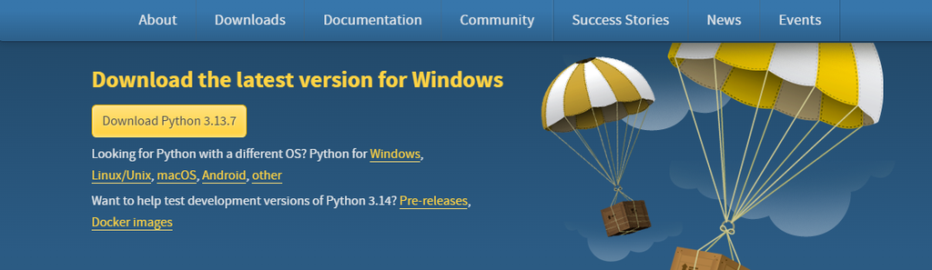

## Step 1: Download Python Package from Python.org

- From your browser type "www.python.org"
- Click the "Downloads" in the menu bar
- Click the Download Python 3.13.7 button
- This will download python package into your computer

# steps before excercise the jupyter notebook

**Slide 2: Environment Setup**

## Step 2: Select Python Environment

1. Select Kernel (The button is at the top right corner) click the button: a pop up window will appear at the top center with "Python Environments" click the "Python Environment" : list of options to select "python environment" move the mouse to the python version you want to use (ex: Python 3.xx.x)